# **Análisis de datos**

## **1. Carga del dataset y exploración inicial**

```python
import os
from google.colab import drive
# Check if Google Drive is already mounted, mount otherwise
if not os.path.ismount('/content/drive'):
    print("Google Drive is not mounted yet. Mounting...")
    drive.mount('/content/drive')
else:
    print("Google Drive is already mounted.")
```

```
Google Drive is not mounted yet. Mounting...
```

```python
import pandas as pd
import numpy as np
import matplotlib.pyplot as plt

df = pd.read_csv("/content/drive/MyDrive/DataLife/data/gold/final_dataset.csv")

df.head()
```

|  | country | year | total_flights | gdp | fossil_co2_emissions |
| --- | --- | --- | --- | --- | --- |
| 0 | Albania | 2016 | 22319 | 1.198867e+10 | 4.538212 |
| 1 | Albania | 2017 | 24559 | 1.325827e+10 | 5.361347 |
| 2 | Albania | 2018 | 25515 | 1.537951e+10 | 5.334114 |
| 3 | Albania | 2019 | 28500 | 1.558511e+10 | 4.983990 |
| 4 | Albania | 2020 | 15288 | 1.524146e+10 | 4.567648 |

```python
df.info()
```

```
<class 'pandas.core.frame.DataFrame'>
RangeIndex: 342 entries, 0 to 341
Data columns (total 5 columns):
 #   Column                Non-Null Count  Dtype
---  ------                --------------  -----
 0   country               342 non-null    object
 1   year                  342 non-null    int64
 2   total_flights         342 non-null    int64
 3   gdp                   342 non-null    float64
 4   fossil_co2_emissions  342 non-null    float64
dtypes: float64(2), int64(2), object(1)
memory usage: 13.5+ KB
```

```python
df.describe()
```

|  | year | total_flights | gdp | fossil_co2_emissions |
| --- | --- | --- | --- | --- |
| count | 342.000000 | 3.420000e+02 | 3.420000e+02 | 342.000000 |
| mean | 2020.000000 | 3.687312e+05 | 5.768051e+11 | 99.857339 |
| std | 2.585772 | 5.429024e+05 | 9.331014e+11 | 148.416900 |
| min | 2016.000000 | 5.383000e+03 | 7.980917e+09 | 1.365483 |
| 25% | 2018.000000 | 4.017600e+04 | 3.903757e+10 | 13.210547 |
| 50% | 2020.000000 | 1.144785e+05 | 2.181470e+11 | 39.137181 |
| 75% | 2022.000000 | 4.405330e+05 | 5.937340e+11 | 88.919081 |
| max | 2024.000000 | 2.283157e+06 | 4.685593e+12 | 789.248936 |

El dataset es una tabla país–año con 342 observaciones (países repetidos en distintos años). Contiene el número total de vuelos (`total_flights`), el PIB en dólares (`gdp`) y la cantidad de emisiones de $CO_2$ fósiles en megatones (`fossil_co2_emissions`) por país y año. No presenta valores faltantes y las variables están en formatos numéricos adecuados para el análisis.

## **2. Análisis descriptivo**

### *¿Cuántos países? ¿Cuántos años por país?*

```python
n_countries = df["country"].nunique()
years = sorted(df["year"].astype(int).unique())
n_years = df["year"].nunique()

print(f"Número de países: {n_countries}")
print(f"Periodo temporal analizado: {min(years)}–{max(years)}")
print(f"Número de años únicos: {n_years}")
```

```
Número de países: 38
Periodo temporal analizado: 2016–2024
Número de años únicos: 9
```

El conjunto de datos analizado incluye información de 38 países a lo largo de un periodo de 9 años (2016–2024), configurando una estructura de datos tipo panel país–año. Todas las variables se encuentran completas y correctamente tipificadas, lo que permite proceder directamente al análisis descriptivo y estadístico.

### *Evolución anual de vuelos y GDP*

```python
by_year = df.groupby("year")[["total_flights","gdp"]].agg(["mean","median","sum"])
by_year
```

| year | total_flights mean | total_flights median | total_flights sum | gdp mean | gdp median | gdp sum |
| --- | --- | --- | --- | --- | --- | --- |
| 2016 | 399510.052632 | 130258.5 | 15181382 | 4.932884e+11 | 1.891940e+11 | 1.874496e+13 |
| 2017 | 413448.552632 | 141840.5 | 15711045 | 5.174325e+11 | 2.052642e+11 | 1.966244e+13 |
| 2018 | 436451.842105 | 148722.0 | 16585170 | 5.550402e+11 | 2.275452e+11 | 2.109153e+13 |
| 2019 | 439708.236842 | 147895.0 | 16708913 | 5.458359e+11 | 2.237108e+11 | 2.074176e+13 |
| 2020 | 190678.052632 | 58930.5 | 7245766 | 5.321034e+11 | 2.104909e+11 | 2.021993e+13 |
| 2021 | 236912.552632 | 71685.5 | 9002677 | 6.058556e+11 | 2.371798e+11 | 2.302251e+13 |
| 2022 | 369518.973684 | 109892.5 | 14041721 | 5.985613e+11 | 2.374444e+11 | 2.274533e+13 |
| 2023 | 405694.184211 | 124671.5 | 15416379 | 6.533197e+11 | 2.676350e+11 | 2.482615e+13 |
| 2024 | 426658.131579 | 137518.5 | 16213009 | 6.898093e+11 | 2.774677e+11 | 2.621275e+13 |

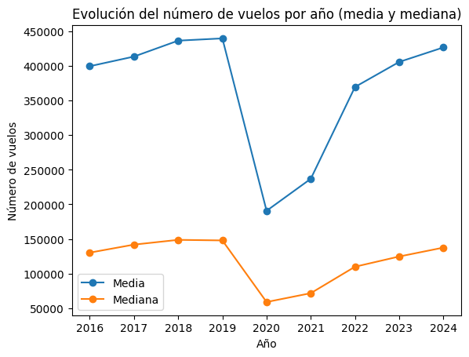

```python
plt.figure()
plt.plot(
    by_year.index,
    by_year[("total_flights", "mean")],
    marker="o",
    label="Media"
)

plt.plot(
    by_year.index,
    by_year[("total_flights", "median")],
    marker="o",
    label="Mediana"
)

plt.xlabel("Año")
plt.ylabel("Número de vuelos")
plt.title("Evolución del número de vuelos por año (media y mediana)")
plt.legend()
plt.show()
```

El análisis temporal por año permite identificar dinámicas diferenciadas a lo largo del periodo 2016–2024. En los años previos a 2020 se observa una tendencia creciente en el número de vuelos, que alcanza su máximo en 2019. En 2020 se produce una caída abrupta del tráfico aéreo, con una reducción significativa tanto de la media como del total agregado de vuelos, coherente con el impacto de la pandemia de COVID-19 sobre el transporte aéreo internacional. A partir de 2021 se aprecia una recuperación progresiva, de modo que en los años más recientes los niveles de vuelos se aproximan nuevamente a los valores previos a la pandemia.

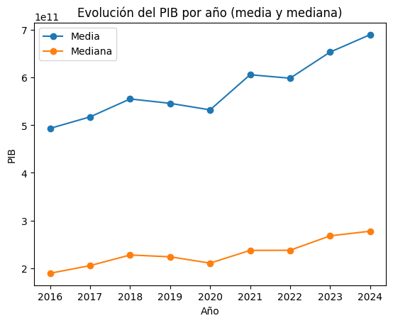

```python
plt.figure()
plt.plot(
    by_year.index,
    by_year[("gdp", "mean")],
    marker="o",
    label="Media"
)

plt.plot(
    by_year.index,
    by_year[("gdp", "median")],
    marker="o",
    label="Mediana"
)

plt.xlabel("Año")
plt.ylabel("PIB")
plt.title("Evolución del PIB por año (media y mediana)")
plt.legend()
plt.show()
```

Por su parte, el PIB muestra una evolución más estable a lo largo del periodo analizado. Aunque en 2020 se registra una ligera desaceleración, la caída es considerablemente menor que la observada en el número de vuelos. Desde 2021, el PIB retoma una senda de crecimiento sostenido, superando en los últimos años los niveles anteriores a la pandemia. Esta divergencia sugiere que el tráfico aéreo presenta una mayor sensibilidad a perturbaciones externas de corto plazo, mientras que el PIB exhibe una mayor resiliencia agregada

### *Distribución de los datos*

```python
df["total_flights"] = df["total_flights"].astype(int)

desc = df[["total_flights", "gdp"]].agg(
    ["mean", "median", "std", "min", "max"]
)

desc.style.format({
    "total_flights": "{:,.0f}",
    "gdp": "{:.2e}"
})
```

|  | total_flights | gdp |
| --- | --- | --- |
| mean | 368,731 | 5.77e+11 |
| median | 114,478 | 2.18e+11 |
| std | 542,902 | 9.33e+11 |
| min | 5,383 | 7.98e+09 |
| max | 2,283,157 | 4.69e+12 |

```python
df[["total_flights","gdp"]].quantile([0.05, 0.25, 0.5, 0.75, 0.95])
```

|  | total_flights | gdp |
| --- | --- | --- |
| 0.05 | 15343.8 | 1.362292e+10 |
| 0.25 | 40176.0 | 3.903757e+10 |
| 0.50 | 114478.5 | 2.181470e+11 |
| 0.75 | 440533.0 | 5.937340e+11 |
| 0.95 | 1855985.1 | 2.871664e+12 |

Los estadísticos descriptivos realizados hasta ahora revelan una elevada heterogeneidad entre países tanto en el número de vuelos como en el PIB. En ambas variables, la media es sustancialmente superior a la mediana, lo que evidencia distribuciones fuertemente asimétricas a la derecha y la presencia de valores extremos correspondientes a economías y mercados aéreos de gran tamaño.

En el caso del número total de vuelos, la mediana se sitúa en torno a 115 mil vuelos, mientras que el 25% de las observaciones no supera los 40 mil vuelos anuales. Sin embargo, el 5% superior alcanza valores por encima de 1,8 millones de vuelos, lo que pone de manifiesto una fuerte concentración del tráfico aéreo.

De forma análoga, el PIB presenta una dispersión muy elevada, con una mediana de aproximadamente 2,2·10¹¹ y un percentil 95 superior a 2,8·10¹². Este patrón justifica el uso de transformaciones logarítmicas en los análisis posteriores con el objetivo de facilitar la interpretación y reducir el impacto de los valores extremos.

#### *Histogramas en escala original*

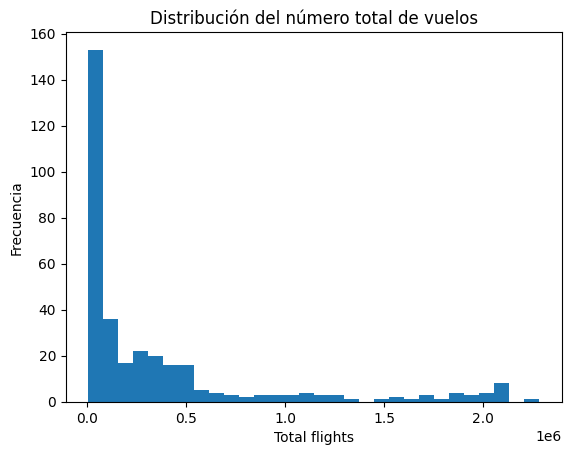

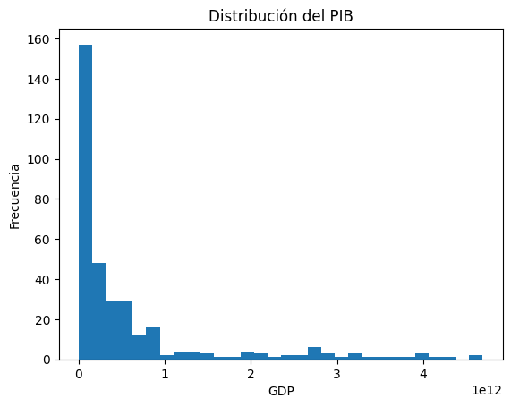

```python
plt.hist(df["total_flights"], bins=30)
plt.xlabel("Total flights")
plt.ylabel("Frecuencia")
plt.title("Distribución del número total de vuelos")
plt.show()

plt.hist(df["gdp"], bins=30)
plt.xlabel("GDP")
plt.ylabel("Frecuencia")
plt.title("Distribución del PIB")
plt.show()
```

Tal y como se observa en los histogramas, ambas variables presentan una fuerte concentración de observaciones en valores bajos y colas largas hacia la derecha, lo que confirma visualmente la elevada asimetría y la presencia de valores extremos descritas en los estadísticos descriptivos.

Dada la elevada asimetría y la presencia de valores extremos en ambas variables, así como las importantes diferencias de escala entre países, se aplican transformaciones logarítmicas al número de vuelos y al PIB en los análisis posteriores. Esta transformación permite reducir la influencia de los outliers, mejorar la interpretación estadística y modelizar relaciones en términos relativos.

#### *Histogramas en escala logaritmica*

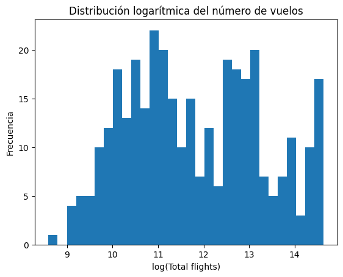

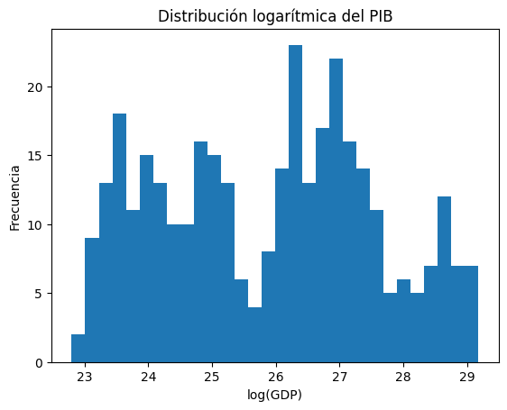

```python
df_log = df.copy()

df_log["total_flights"] = np.log(df_log["total_flights"])
df_log["gdp"] = np.log(df_log["gdp"])

plt.hist(df_log["total_flights"], bins=30)
plt.xlabel("log(Total flights)")
plt.ylabel("Frecuencia")
plt.title("Distribución logarítmica del número de vuelos")
plt.show()

plt.hist(df_log["gdp"], bins=30)
plt.xlabel("log(GDP)")
plt.ylabel("Frecuencia")
plt.title("Distribución logarítmica del PIB")
plt.show()
```

Tras aplicar la transformación logarítmica, ambas distribuciones se aproximan a una forma más simétrica, reduciendo la influencia de los valores extremos y facilitando la comparación entre países.

## **3. Análisis de la relación entre el número de vuelos y el PIB**

#### *Scatter plot Vuelos vs PIB con la escala original*

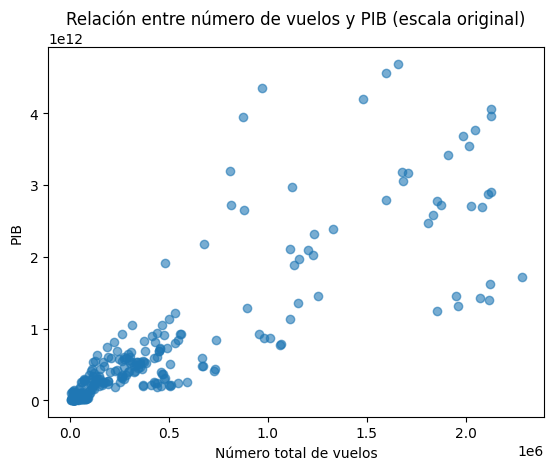

```python
plt.figure()
plt.scatter(df["total_flights"], df["gdp"], alpha=0.6)
plt.xlabel("Número total de vuelos")
plt.ylabel("PIB")
plt.title("Relación entre número de vuelos y PIB (escala original)")
plt.show()
```

La gráfica muestra la relación entre el número total de vuelos y el PIB en escala original. Aunque se aprecia una asociación positiva entre ambas variables, la fuerte concentración de observaciones en valores bajos y la presencia de países con valores extremadamente elevados dificultan la identificación de un patrón claro. Este comportamiento pone de manifiesto la elevada heterogeneidad entre países y justifica el uso de transformaciones logarítmicas para analizar la relación de forma más adecuada.

### *Scatter plot Vuelos vs PIB con la escala logarítmica*

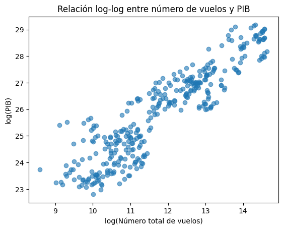

```python
plt.figure()
plt.scatter(df_log["total_flights"], df_log["gdp"], alpha=0.6)
plt.xlabel("log(Número total de vuelos)")
plt.ylabel("log(PIB)")
plt.title("Relación log-log entre número de vuelos y PIB")
plt.show()
```

Esta figura muestra la relación entre el número de vuelos y el PIB en escala logarítmica. A diferencia de la escala original, la transformación logarítmica permite observar una relación aproximadamente lineal entre ambas variables, lo que sugiere una asociación positiva de tipo multiplicativo. Esta representación reduce la influencia de los valores extremos y facilita la interpretación en términos relativos, siendo adecuada para el análisis estadístico posterior.

### *Correlación y contraste de hipótesis*

Una vez analizada la distribución de las variables y explorada visualmente la relación entre el número de vuelos y el PIB mediante representaciones gráficas, en este apartado se procede a evaluar dicha relación de forma cuantitativa. Para ello, se emplean técnicas estadísticas basadas en la escala logarítmica, con el objetivo de reducir la influencia de los valores extremos y facilitar la interpretación en términos relativos. En particular, se calcula el coeficiente de correlación de Pearson y se estima un modelo de regresión lineal en logaritmos, lo que permite analizar la intensidad, significación y naturaleza de la asociación entre el tráfico aéreo y la actividad económica.

Hipótesis del contraste:

- H₀: no hay correlación lineal entre log(vuelos) y log(PIB) (r = 0)
- H₁: sí hay correlación lineal (r ≠ 0) (o positiva, si la planteáis unilateral)

```python
from scipy.stats import pearsonr

r, p_value = pearsonr(df_log["total_flights"], df_log["gdp"])
print("r =", r)
print("p-value =", p_value)
```

```
r = 0.9092753426149695
p-value = 1.7293517010121634e-131
```

El coeficiente de correlación de Pearson entre el logaritmo del número de vuelos y el logaritmo del PIB es $r = 0,909$, lo que indica una relación lineal positiva muy fuerte entre ambas variables. Este valor cercano a 1 sugiere que, en términos relativos, los países con mayor tráfico aéreo tienden a presentar niveles más elevados de PIB.

El valor p asociado al contraste es extremadamente reducido (p-value $\approx 1.7 \cdot 10^{-131}$), muy inferior a cualquier nivel de significación habitual ($\alpha = 0.05$ o $\alpha = 0.01$). En consecuencia, se rechaza la hipótesis nula de ausencia de correlación lineal y se acepta la hipótesis alternativa, concluyendo que existe evidencia estadística muy sólida de una relación lineal significativa entre el número de vuelos y el PIB en escala logarítmica.

### *Regresión log-log: vuelos y PIB*

```python
import statsmodels.api as sm

X = sm.add_constant(df_log["total_flights"])
y = df_log["gdp"]

model = sm.OLS(y, X).fit()
model.summary()
```

OLS Regression Results

| Dep. Variable: | gdp | R-squared: | 0.827 |
| --- | --- | --- | --- |
| Model: | OLS | Adj. R-squared: | 0.826 |
| Method: | Least Squares | F-statistic: | 1623. |
| Date: | Sun, 18 Jan 2026 | Prob (F-statistic): | 1.73e-131 |
| Time: | 17:49:16 | Log-Likelihood: | -363.22 |
| No. Observations: | 342 | AIC: | 730.4 |
| Df Residuals: | 340 | BIC: | 738.1 |
| Df Model: | 1 |  |  |
| Covariance Type: | nonrobust |  |  |

|  | coef | std err | t | P>\|t\| | [0.025 | 0.975] |
| --- | --- | --- | --- | --- | --- | --- |
| const | 13.6820 | 0.305 | 44.860 | 0.000 | 13.082 | 14.282 |
| total_flights | 1.0322 | 0.026 | 40.284 | 0.000 | 0.982 | 1.083 |

| Omnibus: | 1.193 | Durbin-Watson: | 0.445 |
| --- | --- | --- | --- |
| Prob(Omnibus): | 0.551 | Jarque-Bera (JB): | 1.235 |
| Skew: | 0.141 | Prob(JB): | 0.539 |
| Kurtosis: | 2.915 | Cond. No. | 96.3 |

Notes:  
[1] Standard Errors assume that the covariance matrix of the errors is correctly specified.

Los resultados de la regresión logarítmica indican que el número de vuelos presenta un efecto positivo y estadísticamente significativo sobre el PIB. En concreto, el coeficiente estimado sugiere que un aumento del $1\%$ en el número de vuelos se asocia, en promedio, con un incremento aproximado del $1.03\%$ en el PIB. El elevado valor del coeficiente de determinación ($R^2= 0.827$) indica que el tráfico aéreo explica una proporción sustancial de la variabilidad del PIB entre países y años. No obstante, estos resultados deben interpretarse como una asociación estadística y no como una relación causal, dado que el modelo no controla por otros factores económicos relevantes.

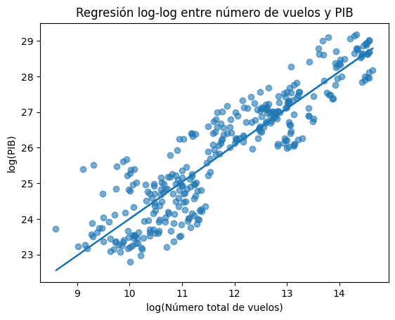

```python
plt.figure()
plt.scatter(df_log["total_flights"], df_log["gdp"], alpha=0.6)
plt.plot(df_log["total_flights"], model.predict(X))
plt.xlabel("log(Número total de vuelos)")
plt.ylabel("log(PIB)")
plt.title("Regresión log-log entre número de vuelos y PIB")
plt.show()
```

La gráfica anterior muestra la regresión log-log entre el número de vuelos y el PIB. La alineación de las observaciones en torno a la recta estimada indica una relación lineal positiva y robusta entre ambas variables en escala logarítmica. La pendiente estimada refleja una elasticidad del PIB respecto al número de vuelos ligeramente superior a la unidad, lo que sugiere que incrementos relativos en el tráfico aéreo se asocian con aumentos proporcionales del nivel de actividad económica. No obstante, la dispersión observada alrededor de la recta pone de manifiesto la influencia de otros factores no incluidos en el modelo.

### **Conclusiones del análisis**

El análisis exploratorio mediante gráficos de dispersión sugiere una relación positiva entre el número de vuelos y el PIB, aunque en escala original esta relación se ve distorsionada por la presencia de outliers. Por este motivo, se aplican transformaciones logarítmicas a ambas variables, lo que permite observar una relación aproximadamente lineal y facilita la interpretación en términos relativos.

En escala logarítmica, el coeficiente de correlación de Pearson entre el número de vuelos y el PIB es elevado ($r = 0,909$) y altamente significativo desde el punto de vista estadístico, lo que indica una asociación lineal positiva muy fuerte entre ambas variables. Este resultado se confirma mediante la estimación de un modelo de regresión lineal log-log, cuyos resultados muestran que un aumento del $1\%$ en el número de vuelos se asocia, en promedio, con un incremento aproximado del $1.03\%$ en el PIB. El modelo presenta un elevado poder explicativo ($R^2= 0.827$), lo que sugiere que el tráfico aéreo explica una proporción sustancial de la variabilidad del PIB entre países y años.

En conjunto, los resultados ponen de manifiesto la existencia de una relación estadísticamente robusta y económicamente relevante entre el tráfico aéreo y la actividad económica. No obstante, los hallazgos deben interpretarse como una asociación y no como una relación causal, dado que el modelo no controla por otros factores macroeconómicos estructurales. El trabajo sienta así una base sólida para futuros análisis que incorporen variables adicionales y técnicas econométricas más avanzadas.

## **4. Análisis adicional y extensiones del modelo**

Una vez establecida la existencia de una relación estadísticamente significativa y robusta entre el número de vuelos y el PIB mediante el análisis log-log básico, resulta pertinente profundizar en dicha relación con el objetivo de evaluar su estabilidad y heterogeneidad. En particular, se analiza si la asociación identificada varía en función del contexto temporal o del tamaño relativo de los países.

Para ello, se desarrollan dos extensiones del análisis principal. En primer lugar, se examina si la relación entre el tráfico aéreo y la actividad económica se ve alterada a partir de 2020, coincidiendo con el impacto de la pandemia de COVID-19, tanto en términos de nivel como de elasticidad. En segundo lugar, se estudia la posible heterogeneidad entre países, evaluando si la relación vuelos–PIB difiere según el tamaño económico o el volumen de tráfico aéreo.

### **Análisis del efecto de la COVID-19 sobre la relación entre vuelos y PIB**

La pandemia de COVID-19 supuso un shock exógeno sin precedentes para el transporte aéreo y la actividad económica a escala global. Las restricciones a la movilidad internacional y la paralización temporal de numerosos sectores productivos provocaron una caída abrupta del número de vuelos a partir de 2020, mientras que el impacto sobre el PIB, aunque significativo, mostró una mayor heterogeneidad entre países y una recuperación relativamente más rápida en muchos casos.

En este contexto, resulta relevante analizar si la relación previamente identificada entre el número de vuelos y el PIB se mantiene estable durante el periodo posterior al inicio de la pandemia o si, por el contrario, se produce un cambio estructural. Para ello, se introduce una variable dicotómica que distingue el periodo posterior a 2020 y se amplía el modelo log-log incorporando tanto un efecto de nivel asociado a la pandemia como un término de interacción que permite evaluar posibles cambios en la elasticidad del PIB respecto al número de vuelos.

Este análisis permite determinar si el impacto de la COVID-19 se limita a una reducción transitoria del nivel de actividad económica o si, además, altera de forma significativa la relación estructural entre el tráfico aéreo y el PIB.

```python
# Preparamos los datos para un mejor manejo posterior
df_log = df.copy()
df_log["log_flights"] = np.log(df_log["total_flights"])
df_log["log_gdp"] = np.log(df_log["gdp"])

# Crear variable indicadora para el período post-COVID
df_log["post_covid"] = (df_log["year"] >= 2020).astype(int)
```

### *Modelo 1: Log-log (el que hicimos antes)*

```python
X = sm.add_constant(df_log["log_flights"])
y = df_log["log_gdp"]

m0 = sm.OLS(y, X).fit()
m0.summary()
```

OLS Regression Results

| Dep. Variable: | log_gdp | R-squared: | 0.827 |
| --- | --- | --- | --- |
| Model: | OLS | Adj. R-squared: | 0.826 |
| Method: | Least Squares | F-statistic: | 1623. |
| Date: | Sun, 18 Jan 2026 | Prob (F-statistic): | 1.73e-131 |
| Time: | 17:55:01 | Log-Likelihood: | -363.22 |
| No. Observations: | 342 | AIC: | 730.4 |
| Df Residuals: | 340 | BIC: | 738.1 |
| Df Model: | 1 |  |  |
| Covariance Type: | nonrobust |  |  |

|  | coef | std err | t | P>\|t\| | [0.025 | 0.975] |
| --- | --- | --- | --- | --- | --- | --- |
| const | 13.6820 | 0.305 | 44.860 | 0.000 | 13.082 | 14.282 |
| log_flights | 1.0322 | 0.026 | 40.284 | 0.000 | 0.982 | 1.083 |

| Omnibus: | 1.193 | Durbin-Watson: | 0.445 |
| --- | --- | --- | --- |
| Prob(Omnibus): | 0.551 | Jarque-Bera (JB): | 1.235 |
| Skew: | 0.141 | Prob(JB): | 0.539 |
| Kurtosis: | 2.915 | Cond. No. | 96.3 |

Notes:  
[1] Standard Errors assume that the covariance matrix of the errors is correctly specified.

```python
beta_0 = m0.params["log_flights"]
print("beta (log_flights):", beta_0)
print("R-squared:", m0.rsquared)
```

```
beta (log_flights): 1.0321811945813169
R-squared: 0.8267816486875699
```

### Modelo 2: regresión log-log con cambio de nivel (post-COVID)

El Modelo 2 incorpora una variable dicotómica `post_covid` (igual a 1 para los años a partir de 2020) con el objetivo de capturar un posible **cambio de nivel** en el PIB tras la pandemia, manteniendo constante la relación entre el tráfico aéreo y la actividad económica. El modelo estimado es:

$$ \log(PIB_{it}) = \alpha + \beta \log(vuelos_{it}) + \gamma\,post\_covid_t + \varepsilon_{it} $$

```python
X = sm.add_constant(df_log[["log_flights", "post_covid"]])
m1 = sm.OLS(y, X).fit()
m1.summary()
```

OLS Regression Results

| Dep. Variable: | log_gdp | R-squared: | 0.849 |
| --- | --- | --- | --- |
| Model: | OLS | Adj. R-squared: | 0.849 |
| Method: | Least Squares | F-statistic: | 956.0 |
| Date: | Sun, 18 Jan 2026 | Prob (F-statistic): | 4.37e-140 |
| Time: | 17:55:21 | Log-Likelihood: | -339.29 |
| No. Observations: | 342 | AIC: | 684.6 |
| Df Residuals: | 339 | BIC: | 696.1 |
| Df Model: | 2 |  |  |
| Covariance Type: | nonrobust |  |  |

|  | coef | std err | t | P>\|t\| | [0.025 | 0.975] |
| --- | --- | --- | --- | --- | --- | --- |
| const | 13.2201 | 0.292 | 45.264 | 0.000 | 12.646 | 13.795 |
| log_flights | 1.0473 | 0.024 | 43.601 | 0.000 | 1.000 | 1.094 |
| post_covid | 0.5109 | 0.072 | 7.136 | 0.000 | 0.370 | 0.652 |

| Omnibus: | 0.040 | Durbin-Watson: | 0.347 |
| --- | --- | --- | --- |
| Prob(Omnibus): | 0.980 | Jarque-Bera (JB): | 0.001 |
| Skew: | 0.003 | Prob(JB): | 1.00 |
| Kurtosis: | 3.002 | Cond. No. | 99.0 |

Notes:  
[1] Standard Errors assume that the covariance matrix of the errors is correctly specified.

```python
beta_1 = m1.params["log_flights"]
beta_2 = m1.params["post_covid"]
print("beta (log_flights):", beta_1)
print("alfa (post_covid):", beta_2)
print("R-squared:", m1.rsquared)
```

```
beta (log_flights): 1.0472546625987622
alfa (post_covid): 0.510933255480347
R-squared: 0.8494015573796619
```

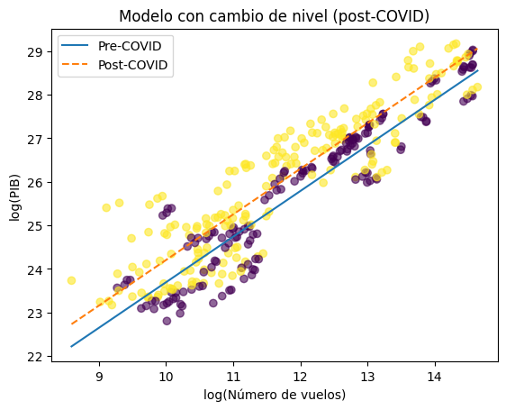

```python
x = np.linspace(df_log["log_flights"].min(), df_log["log_flights"].max(), 100)

# Recta pre-COVID
y_pre = m1.params["const"] + m1.params["log_flights"] * x

# Recta post-COVID
y_post = (m1.params["const"] + m1.params["post_covid"]
          + m1.params["log_flights"] * x)

plt.figure()
plt.scatter(df_log["log_flights"], df_log["log_gdp"],
            c=df_log["post_covid"], alpha=0.6)

plt.plot(x, y_pre, label="Pre-COVID")
plt.plot(x, y_post, linestyle="--", label="Post-COVID")

plt.xlabel("log(Número de vuelos)")
plt.ylabel("log(PIB)")
plt.title("Modelo con cambio de nivel (post-COVID)")
plt.legend()
plt.show()
```

```python
gamma = m1.params["post_covid"]
print("El nivel del PIB, condicionado al número de vuelos, es mayor en el periodo posterior a 2020 en (%):", 100*(np.exp(gamma)-1))
```

```
El nivel del PIB, condicionado al número de vuelos, es mayor en el periodo posterior a 2020 en (%): 66.68460625114285
```

El coeficiente asociado a $ \log(\text{vuelos}) $ es $ \beta = 1.047 $ ($p < 0.001$), lo que indica una relación positiva y estadísticamente significativa: **un incremento del 1% en el número de vuelos se asocia, en promedio, con un aumento aproximado del 1.05% en el PIB**, interpretándose $ \beta $ como una elasticidad. Este resultado confirma que la relación vuelos–PIB es fuerte incluso tras controlar por un posible shock temporal asociado a la pandemia.

Por su parte, el coeficiente de la dummy post-COVID es $ \gamma = 0.5109 $ ($p < 0.001$), lo que sugiere un **desplazamiento de nivel** en $ \log(\text{PIB}) $ para el periodo posterior a 2020, **condicionado al número de vuelos**. En términos porcentuales, el cambio aproximado se puede expresar como:

$$ 100\cdot (e^{\gamma}-1) = 100\cdot(e^{0.5109}-1) \approx 66.7\% $$

Es importante remarcar que este efecto debe interpretarse como una **diferencia de nivel condicionada al tráfico aéreo**, y no como un efecto causal de la pandemia sobre el PIB. En conjunto, la inclusión de `post_covid` mejora el ajuste del modelo ($R^2$ pasa de $0.827$ a $0.849$), lo que indica que captar este cambio temporal aporta capacidad explicativa adicional.

La inclusión de una variable dicotómica post-COVID mejora el ajuste del modelo y resulta estadísticamente significativa. El coeficiente positivo asociado a esta variable indica que, a igualdad de número de vuelos, el nivel del PIB observado en el periodo posterior a 2020 es superior al del periodo pre-pandemia. Este resultado sugiere la existencia de un cambio estructural en la relación entre actividad económica y tráfico aéreo, posiblemente asociado a transformaciones productivas y a la recuperación asimétrica entre ambas variables tras la crisis sanitaria.

### Modelo 3: regresión log-log con interacción (cambio de elasticidad)

El Modelo 3 amplía el enfoque anterior incorporando un término de interacción entre $ \log(\text{vuelos}) $ y la dummy post-COVID. Con ello se evalúa si la **elasticidad** del PIB respecto a los vuelos cambia en el periodo posterior a la pandemia. El modelo estimado es:

$$ \log(\text{PIB}_{it}) = \alpha + \beta \cdot \log(\text{vuelos}_{it}) + \gamma \cdot \text{post_covid}_t + \delta \cdot [\log(\text{vuelos}_{it})\cdot \text{post_covid}_t] + \varepsilon_{it} $$

```python
df_log["interaction"] = df_log["log_flights"] * df_log["post_covid"]

X = sm.add_constant(df_log[["log_flights", "post_covid", "interaction"]])
m2 = sm.OLS(y, X).fit()
m2.summary()
```

OLS Regression Results

| Dep. Variable: | log_gdp | R-squared: | 0.851 |
| --- | --- | --- | --- |
| Model: | OLS | Adj. R-squared: | 0.849 |
| Method: | Least Squares | F-statistic: | 641.0 |
| Date: | Sun, 18 Jan 2026 | Prob (F-statistic): | 4.37e-139 |
| Time: | 18:04:20 | Log-Likelihood: | -338.02 |
| No. Observations: | 342 | AIC: | 684.0 |
| Df Residuals: | 338 | BIC: | 699.4 |
| Df Model: | 3 |  |  |
| Covariance Type: | nonrobust |  |  |

|  | coef | std err | t | P>\|t\| | [0.025 | 0.975] |
| --- | --- | --- | --- | --- | --- | --- |
| const | 12.7160 | 0.431 | 29.483 | 0.000 | 11.868 | 13.564 |
| log_flights | 1.0894 | 0.036 | 30.432 | 0.000 | 1.019 | 1.160 |
| post_covid | 1.4154 | 0.575 | 2.462 | 0.014 | 0.284 | 2.546 |
| interaction | -0.0764 | 0.048 | -1.585 | 0.114 | -0.171 | 0.018 |

| Omnibus: | 0.020 | Durbin-Watson: | 0.346 |
| --- | --- | --- | --- |
| Prob(Omnibus): | 0.990 | Jarque-Bera (JB): | 0.007 |
| Skew: | 0.008 | Prob(JB): | 0.997 |
| Kurtosis: | 2.984 | Cond. No. | 268. |

Notes:  
[1] Standard Errors assume that the covariance matrix of the errors is correctly specified.

```python
beta = m2.params["log_flights"]
delta = m2.params["interaction"]

print("Elasticidad pre-COVID (β):", beta)
print("Elasticidad post-COVID (β+δ):", beta + delta)
print("R-squared:", m2.rsquared)
```

```
Elasticidad pre-COVID (β): 1.0894145937861919
Elasticidad post-COVID (β+δ): 1.0130144626003375
R-squared: 0.8505131430595252
```

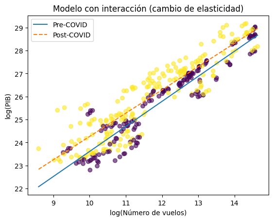

```python
# Recta pre-COVID
y_pre = m2.params["const"] + m2.params["log_flights"] * x

# Recta post-COVID
y_post = (m2.params["const"] + m2.params["post_covid"]
          + (m2.params["log_flights"] + m2.params["interaction"]) * x)

plt.figure()
plt.scatter(df_log["log_flights"], df_log["log_gdp"],
            c=df_log["post_covid"], alpha=0.6)

plt.plot(x, y_pre, label="Pre-COVID")
plt.plot(x, y_post, linestyle="--", label="Post-COVID")

plt.xlabel("log(Número de vuelos)")
plt.ylabel("log(PIB)")
plt.title("Modelo con interacción (cambio de elasticidad)")
plt.legend()
plt.show()
```

El parámetro $ \beta $ representa la elasticidad en el periodo de referencia (años anteriores a 2020). En la estimación obtenida, $ \beta = 1.089 $ ($p < 0.001$), lo que implica que **antes de 2020 un aumento del $1\%$ en vuelos se asocia con un incremento del $1.09\%$ en el PIB**, manteniendo el resto constante.

El coeficiente de interacción es $ \delta = -0.076 $ ($p = 0.114$). Su signo negativo sugiere una **reducción** de la elasticidad en el periodo post-COVID. En concreto, la elasticidad posterior a 2020 se obtiene como $ \beta + \delta $, dando lugar a:

$$ \beta + \delta \approx 1.089 - 0.076 = 1.013 $$

Por tanto, en términos puntuales, **en el periodo post-COVID un aumento del $1\%$ en vuelos se asociaría con un incremento aproximado del $1.01\%$ en el PIB**. Sin embargo, dado que $ \delta $ **no es estadísticamente significativo** al $5\%$ ($p = 0.114$), **no se puede afirmar de forma concluyente** que la elasticidad haya cambiado tras la pandemia. En otras palabras, la evidencia empírica sugiere que la relación vuelos–PIB se mantiene **estructuralmente estable** en términos de pendiente.

Finalmente, el coeficiente $ \gamma = 1.415 $ ($p = 0.014$) sigue capturando un posible **cambio de nivel** del PIB en el periodo posterior a 2020, condicionado al número de vuelos y a la interacción. El ajuste del modelo se mantiene elevado ($R^2 \approx 0.85$), lo que confirma la fuerte capacidad explicativa de los vuelos sobre el PIB en escala logarítmica.

La estimación de un modelo con término de interacción entre el número de vuelos y la dummy post-COVID permite analizar posibles cambios en la elasticidad del PIB respecto al tráfico aéreo tras la pandemia. Los resultados muestran que la elasticidad es ligeramente menor en el periodo posterior a 2020; sin embargo, el coeficiente de interacción no resulta estadísticamente significativo. En consecuencia, no se observa evidencia concluyente de un cambio estructural en la relación vuelos–PIB, que se mantiene positiva y estable antes y después de la COVID-19, si bien se detecta un cambio significativo en el nivel del PIB tras la pandemia.

### Conclusión del impacto del COVID en la relación entre vuelos y PIB

Los resultados obtenidos a partir de los modelos con dummy post-COVID y con término de interacción permiten evaluar si la pandemia supuso un cambio estructural en la relación entre el número de vuelos y el PIB. En primer lugar, la introducción de una variable indicadora para el periodo posterior a 2020 revela la existencia de un **cambio significativo de nivel** en el PIB condicionado al tráfico aéreo, lo que sugiere que, a igualdad de número de vuelos, los niveles de PIB observados en el periodo post-COVID difieren sistemáticamente de los registrados con anterioridad.

En segundo lugar, al permitir que la pendiente de la relación vuelos–PIB varíe mediante un término de interacción, los resultados muestran que la **elasticidad del PIB respecto al número de vuelos se mantiene notablemente estable** entre ambos periodos. Aunque la estimación puntual sugiere una ligera reducción de la elasticidad tras la pandemia, dicha diferencia no resulta estadísticamente significativa, por lo que no se puede afirmar que el vínculo estructural entre el tráfico aéreo y la actividad económica haya cambiado en términos de intensidad.

En conjunto, la evidencia empírica indica que la pandemia de COVID-19 se asocia principalmente con un **desplazamiento del nivel de la actividad económica**, mientras que la relación proporcional entre vuelos y PIB permanece robusta. Estos resultados refuerzan la idea de que el tráfico aéreo continúa siendo un indicador estrechamente vinculado al tamaño de la economía, incluso en presencia de shocks de gran magnitud como el experimentado a partir de 2020.

## **Heterogeneidad entre países en la relación vuelos–PIB**

Los análisis presentados en las secciones anteriores se basan en estimaciones agregadas que asumen implícitamente una relación homogénea entre el número de vuelos y el PIB para todos los países incluidos en la muestra. Sin embargo, esta hipótesis resulta restrictiva dada la elevada diversidad estructural existente entre las economías europeas, tanto en términos de tamaño económico como de grado de apertura, especialización productiva y dependencia del transporte aéreo.

Con el objetivo de relajar este supuesto de homogeneidad, en esta sección se explora explícitamente la **heterogeneidad entre países** en la relación entre el tráfico aéreo y la actividad económica. En particular, se analiza si la elasticidad del PIB respecto al número de vuelos difiere sistemáticamente entre países con distintos niveles de PIB, distinguiendo entre economías de tamaño **bajo**, **medio** y **alto**.

## Clasificación de países por nivel de PIB

Para capturar la heterogeneidad estructural de forma parsimoniosa, los países se clasifican en tres grupos en función de su nivel de PIB. Esta clasificación se realiza utilizando cuantiles del PIB (en logaritmos), de modo que cada grupo contiene aproximadamente el mismo número de observaciones:

- **PIB bajo**
- **PIB medio**
- **PIB alto**

Este enfoque permite comparar la relación vuelos–PIB entre economías de distinto tamaño evitando que los resultados estén dominados por un reducido número de países grandes.

```python
df_log["gdp_group"] = pd.qcut(
    df_log["gdp"],
    q=3,
    labels=["PIB bajo", "PIB medio", "PIB alto"]
)

df_log["gdp_group"].value_counts()
```

| gdp_group | count |
| --- | --- |
| PIB bajo | 114 |
| PIB medio | 114 |
| PIB alto | 114 |

**dtype:** int64

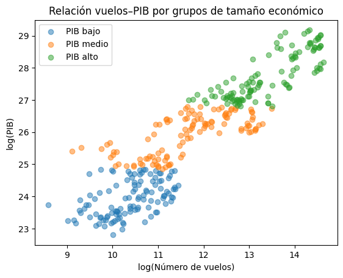

```python
plt.figure()

for group in ["PIB bajo", "PIB medio", "PIB alto"]:
    sub = df_log[df_log["gdp_group"] == group]
    plt.scatter(
        sub["log_flights"],
        sub["log_gdp"],
        alpha=0.5,
        label=group
    )

plt.xlabel("log(Número de vuelos)")
plt.ylabel("log(PIB)")
plt.title("Relación vuelos–PIB por grupos de tamaño económico")
plt.legend()
plt.show()
```

La Figura muestra la relación entre el logaritmo del número de vuelos y el logaritmo del PIB diferenciando por grupos de tamaño económico. Se observa que, aunque la relación positiva entre ambas variables está presente en los tres grupos, existen diferencias claras tanto en el nivel como en la dispersión de los datos.

En particular, los países con **PIB alto** se concentran en niveles elevados de tráfico aéreo y actividad económica, mientras que los países con **PIB bajo** presentan valores significativamente menores en ambas dimensiones. Este patrón sugiere que la relación estimada a nivel agregado podría ocultar diferencias relevantes en la intensidad con la que el tráfico aéreo se asocia al crecimiento económico según el tamaño del país.

#### *Regresiones log-log por grupo de PIB*

Para cuantificar formalmente estas diferencias, se estiman regresiones log-log separadas para cada grupo de países. En cada caso se estima el siguiente modelo:

$$ \log(\text{PIB}_{it}) = \alpha_g + \beta_g \cdot \log(\text{vuelos}_{it}) + \varepsilon_{it}, $$

donde el subíndice $g$ indica el grupo de PIB al que pertenece el país.

```python
rows = []
for group in ["PIB bajo", "PIB medio", "PIB alto"]:
    sub = df_log[df_log["gdp_group"] == group]
    X = sm.add_constant(sub["log_flights"])
    y = sub["log_gdp"]
    model = sm.OLS(y, X).fit()

    rows.append({
        "grupo": group,
        "n": len(sub),
        "beta": model.params["log_flights"],
        "p_value": model.pvalues["log_flights"],
        "R2": model.rsquared
    })

pd.DataFrame(rows)
```

|  | grupo | n | beta | p_value | R2 |
| --- | --- | --- | --- | --- | --- |
| 0 | PIB bajo | 114 | 0.418326 | 8.300350e-08 | 0.227160 |
| 1 | PIB medio | 114 | 0.431443 | 2.418934e-17 | 0.474555 |
| 2 | PIB alto | 114 | 0.730777 | 1.923047e-27 | 0.652166 |

Los resultados muestran que la elasticidad del PIB respecto al número de vuelos es **positiva y estadísticamente significativa** en los tres grupos, lo que confirma la existencia de una relación robusta entre ambas variables independientemente del tamaño económico. No obstante, la magnitud de dicha elasticidad difiere de forma notable entre grupos.

- En los países con **PIB bajo**, la elasticidad estimada es de aproximadamente $0.42$, lo que indica una respuesta menos que proporcional del PIB ante aumentos en el tráfico aéreo.
- En el grupo de **PIB medio**, la elasticidad es ligeramente superior, alrededor de $0.43$, sugiriendo que el tráfico aéreo desempeña un papel relativamente más limitado en estas economías.
- Por el contrario, en los países con **PIB alto**, la elasticidad asciende a aproximadamente $0.73$, reflejando una mayor vinculación entre conectividad aérea y tamaño de la economía.

Asimismo, el poder explicativo del modelo aumenta con el nivel de PIB, como indican los valores crecientes del $R^2$, lo que sugiere que en economías grandes el tráfico aéreo está más estrechamente integrado en la estructura productiva.

### *Igualdad de elasticidades entre grupos de países*

Con el objetivo de evaluar formalmente si la elasticidad del PIB respecto al número de vuelos difiere entre países según su nivel de PIB, se estima un modelo log-log con interacciones entre el logaritmo del número de vuelos y variables indicativas de los grupos de PIB.

El modelo toma como grupo de referencia a los países con PIB bajo, permitiendo que tanto el nivel como la pendiente de la relación vuelos–PIB difieran para los países de PIB medio y alto. En este contexto, las interacciones capturan posibles diferencias en la elasticidad del PIB respecto al tráfico aéreo.

Formalmente, el modelo estimado es:

$$ \log(\text{PIB}_{it}) = \alpha + \beta \log(\text{vuelos}_{it}) + \delta_{medio} D_{medio,it} + \delta_{alto} D_{alto,it} + \gamma_{medio} D_{medio,it} \log(\text{vuelos}_{it}) + \gamma_{alto} D_{alto,it} \log(\text{vuelos}_{it}) + \varepsilon_{it} $$

donde:

- $\beta$ representa la elasticidad del PIB respecto a los vuelos en el grupo de **PIB bajo** (grupo de referencia),
- $\gamma_{medio}$ y $\gamma_{alto}$ capturan los cambios en dicha elasticidad para los países de **PIB medio** y **PIB alto**, respectivamente.

```python
df_log["D_medio"] = (df_log["gdp_group"] == "PIB medio").astype(int)
df_log["D_alto"]  = (df_log["gdp_group"] == "PIB alto").astype(int)

df_log["int_medio"] = df_log["log_flights"] * df_log["D_medio"]
df_log["int_alto"]  = df_log["log_flights"] * df_log["D_alto"]

X = sm.add_constant(
    df_log[["log_flights", "D_medio", "D_alto", "int_medio", "int_alto"]]
)
y = df_log["log_gdp"]

m_het = sm.OLS(y, X).fit()
m_het.summary()
```

OLS Regression Results

| Dep. Variable: | log_gdp | R-squared: | 0.928 |
| --- | --- | --- | --- |
| Model: | OLS | Adj. R-squared: | 0.927 |
| Method: | Least Squares | F-statistic: | 870.2 |
| Date: | Sun, 18 Jan 2026 | Prob (F-statistic): | 7.68e-190 |
| Time: | 18:20:35 | Log-Likelihood: | -212.36 |
| No. Observations: | 342 | AIC: | 436.7 |
| Df Residuals: | 336 | BIC: | 459.7 |
| Df Model: | 5 |  |  |
| Covariance Type: | nonrobust |  |  |

|  | coef | std err | t | P>\|t\| | [0.025 | 0.975] |
| --- | --- | --- | --- | --- | --- | --- |
| const | 19.5947 | 0.710 | 27.617 | 0.000 | 18.199 | 20.990 |
| log_flights | 0.4183 | 0.068 | 6.131 | 0.000 | 0.284 | 0.553 |
| D_medio | 1.3077 | 0.875 | 1.495 | 0.136 | -0.413 | 3.028 |
| D_alto | -1.6356 | 1.007 | -1.624 | 0.105 | -3.617 | 0.346 |
| int_medio | 0.0131 | 0.081 | 0.162 | 0.872 | -0.146 | 0.173 |
| int_alto | 0.3125 | 0.087 | 3.610 | 0.000 | 0.142 | 0.483 |

| Omnibus: | 14.988 | Durbin-Watson: | 0.477 |
| --- | --- | --- | --- |
| Prob(Omnibus): | 0.001 | Jarque-Bera (JB): | 7.952 |
| Skew: | 0.175 | Prob(JB): | 0.0188 |
| Kurtosis: | 2.340 | Cond. No. | 749. |

Notes:  
[1] Standard Errors assume that the covariance matrix of the errors is correctly specified.

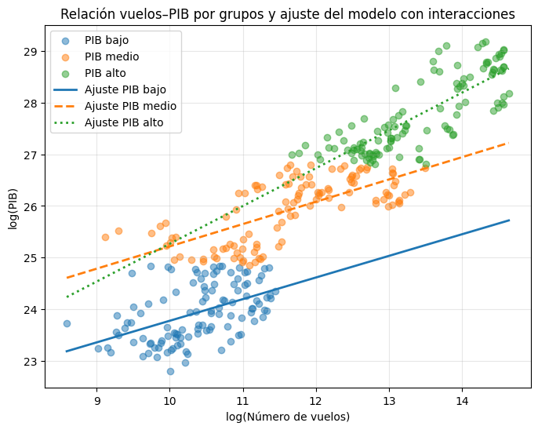

```python
plt.figure(figsize=(8,6))

# 1) Scatter por grupos (tus puntos)
for group in ["PIB bajo", "PIB medio", "PIB alto"]:
    sub = df_log[df_log["gdp_group"] == group]
    plt.scatter(
        sub["log_flights"],
        sub["log_gdp"],
        alpha=0.5,
        label=group
    )

# 2) Construir las rectas del modelo con interacciones (m_het)
x_grid = np.linspace(df_log["log_flights"].min(), df_log["log_flights"].max(), 200)

b0 = m_het.params["const"]
b1 = m_het.params["log_flights"]

b_medio = m_het.params["D_medio"]
b_alto  = m_het.params["D_alto"]

g_medio = m_het.params["int_medio"]
g_alto  = m_het.params["int_alto"]

# Predicciones por grupo
y_bajo  = b0 + b1 * x_grid
y_medio = (b0 + b_medio) + (b1 + g_medio) * x_grid
y_alto  = (b0 + b_alto)  + (b1 + g_alto)  * x_grid

# 3) Dibujar las rectas encima
plt.plot(x_grid, y_bajo,  linewidth=2, label="Ajuste PIB bajo")
plt.plot(x_grid, y_medio, linewidth=2, linestyle="--", label="Ajuste PIB medio")
plt.plot(x_grid, y_alto,  linewidth=2, linestyle=":",  label="Ajuste PIB alto")

# 4) Formato final
plt.xlabel("log(Número de vuelos)")
plt.ylabel("log(PIB)")
plt.title("Relación vuelos–PIB por grupos y ajuste del modelo con interacciones")
plt.legend()
plt.grid(alpha=0.3)
plt.show()
```

La gráfica representa la relación entre el número de vuelos y el PIB en escala logarítmica, distinguiendo entre países según su nivel de PIB e incorporando las rectas de ajuste estimadas a partir del modelo con interacciones. Las diferencias en las pendientes de las rectas reflejan visualmente la heterogeneidad en la elasticidad del PIB respecto al tráfico aéreo entre grupos, proporcionando una interpretación gráfica del contraste formal de igualdad de elasticidades realizado a continuación.

Los resultados del modelo muestran que la elasticidad base del PIB respecto al número de vuelos para los países de PIB bajo es positiva y estadísticamente significativa ($\beta \approx 0.42$), lo que indica que un aumento del $1\%$ en el número de vuelos se asocia, en promedio, con un incremento del PIB inferior al proporcional en este grupo de economías.

Los coeficientes de nivel ($\delta_{medio}$ y $\delta_{alto}$) indican diferencias en el nivel medio del PIB entre grupos, una vez controlado por el tráfico aéreo, aunque estos coeficientes no son el foco principal del análisis de elasticidades.

En cuanto a los términos de interacción:

- El coeficiente $\gamma_{medio}$ es positivo y no significativo al $5\%$, lo que sugiere que la elasticidad del PIB respecto a los vuelos en los países de PIB medio no difiere de forma concluyente de la del grupo de referencia.
- El coeficiente $\gamma_{alto}$ es positivo y significativo, lo que apunta a una elasticidad mayor en los países de PIB alto, consistente con una mayor integración del transporte aéreo en economías más avanzadas.

#### *Prueba F de Fisher*

Formalmente, se contrasta la siguiente hipótesis nula:

- $H_0$: la elasticidad del PIB respecto a los vuelos es la misma en todos los grupos.
- $H_1$: al menos una elasticidad difiere entre grupos.

```python
f_test = m_het.f_test("int_medio = 0, int_alto = 0")
f_test
```

```
<class 'statsmodels.stats.contrast.ContrastResults'>
<F test: F=10.973556686725319, p=2.417850112425851e-05, df_denom=336, df_num=2>
```

El contraste F arroja un estadístico elevado ($F = 10.97$) con un **p-valor inferior a $0.001$**, lo que conduce al **rechazo de la hipótesis nula** de igualdad de elasticidades entre grupos de países.

Por tanto, los resultados del contraste confirman que la relación entre el tráfico aéreo y la actividad económica **no es homogénea entre países**, y que la elasticidad del PIB respecto al número de vuelos depende del nivel de desarrollo económico. En particular, el impacto relativo del tráfico aéreo sobre el PIB tiende a ser mayor en economías de mayor tamaño, lo que sugiere diferencias estructurales en el papel del transporte aéreo dentro del sistema productivo.

Este hallazgo refuerza la evidencia obtenida a partir de las estimaciones separadas por grupos y pone de manifiesto la importancia de considerar la heterogeneidad entre países en el análisis de la relación entre conectividad aérea y crecimiento económico.

## Conclusión: heterogeneidad entre países en la relación vuelos–PIB

El análisis empírico confirma que la relación entre el número de vuelos y el nivel de actividad económica es positiva y estadísticamente significativa en todos los países analizados. Sin embargo, la magnitud de dicha relación presenta una heterogeneidad clara y sistemática entre países, que no puede interpretarse únicamente en términos de tamaño económico, sino que responde de forma más profunda a diferencias en la estructura productiva, el grado de apertura y el papel del transporte aéreo dentro de cada economía.

En las economías de PIB alto, como España, Francia, Italia, Alemania, Países Bajos o Reino Unido, la elasticidad del PIB respecto al número de vuelos es sensiblemente mayor. Este resultado es coherente con el peso que el transporte aéreo tiene en estos países como infraestructura económica clave. En primer lugar, se trata de economías altamente abiertas, con una intensa integración en los flujos internacionales de comercio, inversión y movilidad laboral. En segundo lugar, muchas de ellas presentan una especialización significativa en sectores intensivos en movilidad, como el turismo, los servicios empresariales avanzados, las finanzas internacionales o las cadenas de valor multinacionales.

En este contexto, el tráfico aéreo no actúa únicamente como un reflejo del nivel de actividad económica, sino como un mecanismo amplificador del crecimiento. Un incremento del número de vuelos facilita la llegada de turistas, la realización de viajes de negocios, la coordinación internacional de empresas y la atracción de inversión extranjera, generando efectos de arrastre sobre múltiples sectores de la economía. De ahí que la elasticidad estimada sea mayor: el transporte aéreo está profundamente integrado en el proceso de generación de PIB.

En economías como España, Portugal, Italia o Francia, este efecto es especialmente relevante debido a la elevada dependencia del turismo internacional y de los servicios asociados. En estos países, una variación en la conectividad aérea tiene un impacto directo sobre el volumen de actividad económica, lo que se traduce en una relación vuelos–PIB más elástica.

Por el contrario, en los países de PIB medio, la elasticidad estimada es menor. Estas economías, entre las que se encuentran Austria, República Checa, Hungría, Grecia o Eslovaquia, presentan estructuras productivas más diversificadas, con un mayor peso relativo de la industria, el mercado interno o los flujos comerciales terrestres dentro de Europa. En estos casos, el transporte aéreo desempeña un papel relevante, pero no central, actuando más como un factor complementario que como un motor principal de la actividad económica. Como consecuencia, los incrementos en el número de vuelos se traducen en aumentos del PIB de menor magnitud relativa.

Desde esta perspectiva, el tráfico aéreo en estos países actúa más como un indicador acompañante del desarrollo económico que como un determinante estructural del crecimiento. Un aumento del número de vuelos refleja una mejora en la integración internacional, pero no genera efectos multiplicadores tan intensos como en economías más avanzadas y orientadas a servicios.

El contraste formal de igualdad de elasticidades confirma estadísticamente estas diferencias, reforzando la interpretación de que la relación vuelos–PIB depende del modelo económico subyacente de cada país. En conjunto, los resultados sugieren que la elasticidad del PIB respecto al número de vuelos captura no solo una relación cuantitativa entre ambas variables, sino también la forma en que cada economía se inserta en los flujos internacionales de movilidad, comercio y servicios.

Desde el punto de vista de política económica, esta evidencia implica que las inversiones en infraestructuras aeroportuarias y conectividad aérea pueden generar retornos económicos elevados en países con economías abiertas y especializadas en sectores intensivos en movilidad, mientras que en economías menos desarrolladas estos efectos pueden ser más limitados y depender de estrategias complementarias de diversificación productiva e integración internacional

## 6. Relación entre el PBI y las emisiones de CO$_2$ fósiles

El análisis de la relación entre riqueza y transporte aéreo quedaría incompleto sin evaluar la eficiencia climática de los actores que lideran el mercado continental. Como punto de partida, se presenta un diagrama de dispersión (scatterplot) bajo escalas logarítmicas que evidencia una correlación positiva directa entre el volumen del PIB y el nivel de emisiones brutas de $CO_2$. El uso de la transformación logarítmica resulta fundamental en este análisis para normalizar las asimetrías de magnitud entre las distintas potencias europeas, permitiendo observar una tendencia estructural clara: históricamente, el tamaño de la economía ha determinado el volumen de su huella de carbono. Esta visualización establece la línea de base necesaria para entender por qué la métrica de intensidad (CO$_2$/PIB), que analizaremos a continuación, es la clave para identificar qué países están logrando romper este vínculo tradicional.

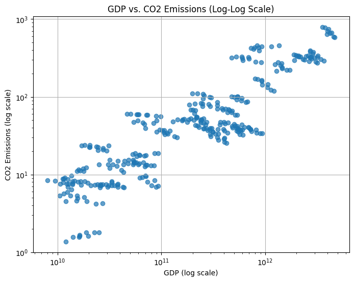

```python
import matplotlib.pyplot as plt
import seaborn as sns

plt.figure(figsize=(8, 6))
plt.scatter(df['gdp'], df['fossil_co2_emissions'], alpha=0.7)
plt.title('GDP vs. CO2 Emissions (Log-Log Scale)')
plt.xlabel('GDP (log scale)')
plt.ylabel('CO2 Emissions (log scale)')
plt.xscale('log')
plt.yscale('log')
plt.grid(True)
plt.show()
```

A continuación, se analiza como ha evolucionado la implicación ambiental de las principales $10$ economías europeas en el periodo $2016-2024$, para esta tarea se utilizará el ratio CO$_{2}$/PIB. Esta métrica resulta fundamental para entender la evolución de la intensidad de carbono en los últimos nueve años, permitiéndonos identificar qué naciones están liderando una transición efectiva hacia un modelo de crecimiento que ya no depende de incrementar las emisiones a la atmósfera. Primero analizamos cuáles son las $10$ principales potencias europeas de los ultimos $9$ años en cuanto a su PIB medio.

```python
df_mean = df.groupby('country').mean().reset_index()
```

```python
top10 = df_mean.sort_values('gdp', ascending=False).head(10)['country'].unique()
```

```python
df_top10 = df[df['country'].isin(top10)]
```

```python
df_top10['co2/gdp'] = df_top10['fossil_co2_emissions']/df_top10['gdp']
```

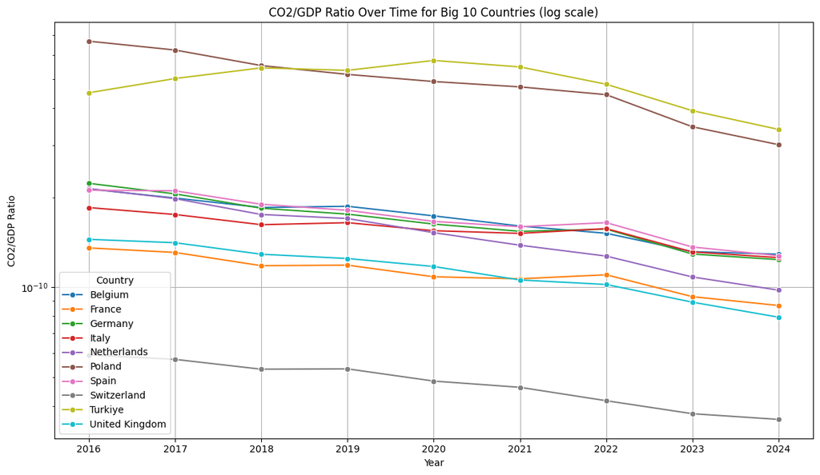

```python
plt.figure(figsize=(12, 7))
sns.lineplot(data=df_top10, x='year', y='co2/gdp', hue='country', marker='o')
plt.title('CO2/GDP Ratio Over Time for Big 10 Countries (log scale)')
plt.xlabel('Year')
plt.ylabel('CO2/GDP Ratio')
plt.yscale('log')
plt.grid(True)
plt.legend(title='Country')
plt.xticks(df_top10['year'].unique())
plt.tight_layout()
plt.show()
```

Este gráfico de líneas revela una tendencia generalizada hacia la eficiencia, aunque con brechas estructurales marcadas entre los países analizados.Al observar los extremos de la gráfica, se identifican comportamientos claramente diferenciados:

- Liderazgo en eficiencia (Extremo inferior): Suiza destaca como el país con el ratio más bajo de todo el grupo, posicionándose significativamente por debajo del resto durante todo el periodo. Su trayectoria descendente refuerza su papel como la economía más descarbonizada en relación con su riqueza generada.
- Alta intensidad de emisiones (Extremo superior): En la parte alta de la tabla se sitúan Polonia y Turquía. Mientras que Polonia muestra una reducción constante y pronunciada de su ratio, Turquía ha mantenido niveles de intensidad más elevados y persistentes, llegando a liderar el gráfico en los últimos años del estudio. Ambos países representan el mayor desafío de transición dentro de este "Big 10".

Sin embargo, debido a la naturaleza de la escala logarítmica y a la proximidad en el rendimiento de las potencias restantes (como Francia, Reino Unido, Alemania o España), existe un solapamiento visual en la franja central que dificulta el análisis pormenorizado de sus trayectorias. Por este motivo, en la siguiente gráfica se realizará un "zoom" analítico en este grupo intermedio, permitiendo visualizar con mayor nitidez las dinámicas de convergencia y las sutiles diferencias en su compromiso medioambiental.

```python
df_mid = df_top10[~df_top10['country'].isin(['Switzerland', 'Poland', 'Turkiye'])]
```

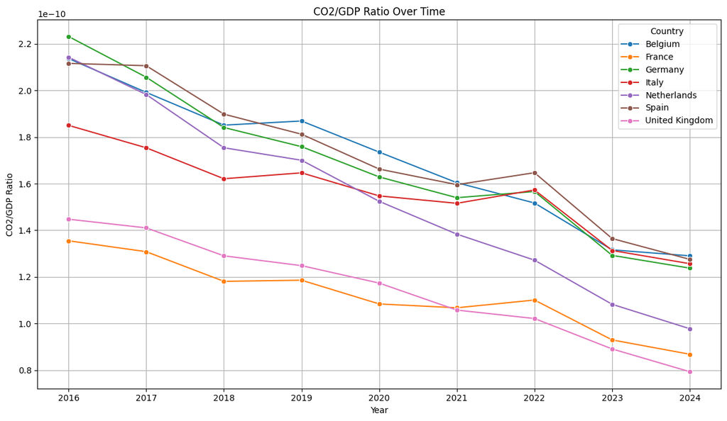

```python
plt.figure(figsize=(12, 7))
sns.lineplot(data=df_mid, x='year', y='co2/gdp', hue='country', marker='o')
plt.title('CO2/GDP Ratio Over Time')
plt.xlabel('Year')
plt.ylabel('CO2/GDP Ratio')
#plt.yscale('log')
plt.grid(True)
plt.legend(title='Country')
plt.xticks(df_top10['year'].unique())
plt.tight_layout()
plt.show()
```

Este análisis del ratio de intensidad de carbono (CO$_2$/PIB) revela la compleja dinámica entre el crecimiento económico y el impacto ambiental en las principales potencias europeas. Tras observar los extremos, podemos desglosar el comportamiento del resto del grupo para entender mejor sus disparidades:

- El segmento de eficiencia intermedia: Por encima de Suiza, pero claramente diferenciados del bloque central, encontramos a Reino Unido, Francia y Países Bajos. Estos tres países han logrado consolidar una trayectoria de mejora constante, manteniéndose en una "zona de seguridad" intermedia que los separa de las economías con mayor dependencia de los combustibles fósiles.
  - Es especialmente reseñable el caso de los Países Bajos: de este grupo de vanguardia, era el país que partía de un punto más desfavorecido en 2016, con una intensidad de carbono significativamente superior a la de sus pares directos. Sin embargo, su evolución en estos nueve años muestra una de las pendientes de descenso más acusadas, logrando cerrar la brecha y consolidarse en los niveles de eficiencia de las economías más limpias.
- El bloque de convergencia (España, Italia, Bélgica y Alemania): El resto de los países analizados muestran un comportamiento sumamente similar, agrupándose en una franja muy estrecha hacia 2024. Sin embargo, dentro de esta similitud hay matices importantes:
  - Italia: Resulta ser el país "peor parado" dentro de este grupo compacto. Si observamos el punto de partida en 2016, Italia gozaba de una posición de ventaja relativa frente a sus pares; sin embargo, su evolución ha sido más plana, perdiendo ese liderazgo inicial y terminando empatada con países que partían de niveles de intensidad mucho más altos.
  - Alemania: Su caso es digno de mención. Al ser la economía más desarrollada de Europa por volumen de PIB, la inercia de su potente sector industrial suele penalizarla en este tipo de métricas. Pese a este "handicap" estructural, resulta significativo que Alemania logre mantenerse empatada en eficiencia con el resto del bloque central, demostrando un esfuerzo de descarbonización que compensa su enorme escala productiva.

Este panorama general confirma que, aunque casi todas las potencias están logrando reducir su intensidad de carbono, el ritmo y la capacidad de cada nación para "limpiar" su riqueza dependen fuertemente de su punto de partida y de su estructura económica subyacente.